# Tarea 1.2 - Bases de Datos Avanzadas

## Bases de datos Documentales

| Rafael Calvo | Victor Franchis | Javier Levio |
| --- | --- | --- |
| 201273506-8 | 201273566-1 | 201273598-k |

### Preguntas:

- Cuales son los 5 países con los mejores vinos rankeados promedio?
- Cuales son los terminos descriptivos a los que mas se hacen alusion?
- Posibles relaciones entre ellos.
- Qué terminos son los mas comunes en 3 cepas de vino distintas?
- Generar una nube de palabras con los N terminos mas comunes.
- Es posible identificar clusters de algun tipo entre los datos analizados?

### Desarrollo:

*Importante! hubo consultas (pregunta 1) que solo funcionaron en mongo 3.4, favor de revisar su versión ya que la primera pregunta trajo problemasdebido a este factor.*

Inicialmente se importa la libreria RMongo y nos conectamos a la BD “*BDA*”. Recordar que esta fue creada en la parte 1.1 de la tarea con la coleccion “*wines_col*”.

```r
library(RMongo)
mongo = mongoDbConnect("BDA", "localhost", 27017)
mongo
```

```
An object of class "RMongo"
Slot "javaMongo":
[1] "Java-Object{rmongo.RMongo@6b9651f3}"
```

```r
example = dbGetQuery(mongo, "wines_col", '{variety: "Gelber Traminer"}')
print(example, quote = TRUE, row.names = FALSE)
```

```
   country         taster_name taster_twitter_handle
 "Austria" "Anne KrebiehlÂ MW"         "@AnneInVino"
                                                                                                                                                                                                                                                                                                            …
 "The musky touch of botryrtis clings to the mellow, sweet ripeness of juicy Mirabelle plums and candied citrus on the nose. The palate follows with a supremely balanced sweetness that's nonetheless bright and luminous with lemony freshness. A floral perfume fills the palate with a fragrance that la…
                                                                             title
 "Salomon-Undhof 2009 Rosengold Beeranauslese Gelber Traminer (NiederÃ¶sterreich)"
 points            province           variety price
   "95" "NiederÃ¶sterreich" "Gelber Traminer"  "35"
                       X_id               designation           winery
 "5ae279bd330cef08b7480221" "Rosengold Beeranauslese" "Salomon-Undhof"
 region_1 region_2
     "NA"     "NA"
```

#### - Cuales son los 5 paises con los mejores vinos rankeados promedio?

```r
# library(RMongo)
# mongo = mongoDbConnect("BDA","localhost",27017)
output = dbAggregate(mongo,"wines_col", c(
  '{$group: {_id: "$country", promedio: {$avg: "$points"}}}',
  '{$sort: {promedio: -1}}',
  '{$limit: 5}'
))
```

[output not shown]

[output not shown]

#### - Que terminos son los mas comunes en 3 cepas de vino distintas?

*Nota: Se interpreta esta pregunta como el tomar 3 cepas a gusto y buscar los terminos mas comunes entre estas. De tener que analizarse estas por separado, la diferencia yace en tener que hacer 3 veces el mismo procedimiento, una vez por cada cepa a analizar.*

Primero se realiza una query para obtener solo los datos de 3 tipos de cepas:

```r
library(tm)
collection = dbGetQuery(mongo, "wines_col", '{$or: [{variety: "Tinta del Pais"},{variety: "Gelber Traminer"},{variety: "Terrantez"}]}')
descriptions = collection["description"][[1]]
```

Posteriormente lo transformamos a un *corpus* tal como se vio en clases. Como en este caso no se estan leyendo archivos se hace mediante la funcion *VectorSource*:

```r
docs = Corpus(VectorSource(descriptions))
```

Seguido de esto se crea un transformador de contenido llamado *toSpace* para eliminar todos los caracteres innecesarios que no correspondan a palabras, además de pasar cada letra a minúsculas y eliminar las *stopwords*:

```r
toSpace = content_transformer(function(x, pattern) {return (gsub(pattern, " ", x))})
# eliminacion de caracteres
docs = tm_map(docs, toSpace, "-")
docs = tm_map(docs, toSpace, ":")
docs = tm_map(docs, removePunctuation)
docs = tm_map(docs, toSpace, "'")
docs = tm_map(docs, toSpace, "'")
docs = tm_map(docs, toSpace, " - ")
docs = tm_map(docs, toSpace, "-")
docs = tm_map(docs, toSpace, "\n")
docs = tm_map(docs, toSpace, "   ")
docs = tm_map(docs, toSpace, "  ")
# Transformar a minusculas
docs = tm_map(docs,content_transformer(tolower))
# Eliminar digitos
docs = tm_map(docs, removeNumbers)
# Remover stopwords
docs = tm_map(docs, removeWords, stopwords("english"))
# Espacios en blanco
docs = tm_map(docs, stripWhitespace)
dtm= DocumentTermMatrix(docs)
dtm
```

```
<<DocumentTermMatrix (documents: 4, terms: 116)>>
Non-/sparse entries: 127/337
Sparsity           : 73%
Maximal term length: 13
Weighting          : term frequency (tf)
```

Seguido de esto se procede a Contar la frecuencia de ocurrencia de cada palabra en el corpus, sumando las filas:

```r
freq = colSums(as.matrix(dtm))
# Ordenar las frecuencias
ord = order(freq,decreasing=TRUE)
# Listar los terminos mas frecuentes
freq[head(ord)]
```

```
    palate blackberry     aromas    balance     cassis      drink
         4          3          2          2          2          2
```

De esto se desprende que las palabras mas repetidas son palate y blackberry.

#### - Generar una nube de palabras con los N terminos mas comunes.

Se realiza una consulta similar a la inicial para obtener todas las descripciones:

```r
library(tm)
collection = dbGetQuery(mongo, "wines_col", '')
descriptions = collection["description"][[1]]
docs = Corpus(VectorSource(descriptions))
docs
```

```
<<SimpleCorpus>>
Metadata:  corpus specific: 1, document level (indexed): 0
Content:  documents: 1000
```

Se puede revisar cada descripcion con el siguiente comando:

```r
writeLines(as.character(docs[[2]]))
```

```
Pineapple rind, lemon pith and orange blossom start off the aromas. The palate is a bit more opulent, with notes of honey-drizzled guava and mango giving way to a slightly astringent, semidry finish.
```

Se procede a limpiar de caracteres y palabras innecesarias igual que en preguntas anteriores:

```r
docs = tm_map(docs, toSpace, "-")
docs = tm_map(docs, toSpace, ":")
docs = tm_map(docs, removePunctuation)
docs = tm_map(docs, toSpace, "'")
docs = tm_map(docs, toSpace, "'")
docs = tm_map(docs, toSpace, " - ")
docs = tm_map(docs, toSpace, "-")
docs = tm_map(docs, toSpace, "\n")
docs = tm_map(docs, toSpace, "   ")
docs = tm_map(docs, toSpace, "  ")
docs = tm_map(docs,content_transformer(tolower))
docs = tm_map(docs, removeNumbers)
docs = tm_map(docs, removeWords, stopwords("english"))
docs = tm_map(docs, stripWhitespace)
```

Nuevamente revisamos la descripcion para ver si hubo cambios:

```r
# Inspeccionar el nuevo contenido
writeLines(as.character(docs[[2]]))
```

```
pineapple rind lemon pith orange blossom start aromas palate bit opulent notes honey drizzled guava mango giving way slightly astringent semidry finish
```

Por ahora no se considerara el uso de stemming, por lo que se pasara directo a la construccion de una matriz de documentos y terminos:

```r
dtm= DocumentTermMatrix(docs)
dtm
```

```
<<DocumentTermMatrix (documents: 1000, terms: 3938)>>
Non-/sparse entries: 24895/3913105
Sparsity           : 99%
Maximal term length: 17
Weighting          : term frequency (tf)
```

Revisando el contenido se observa que hubo resultados:

```r
inspect(dtm[10:15,1:7])
```

```
<<DocumentTermMatrix (documents: 6, terms: 7)>>
Non-/sparse entries: 4/38
Sparsity           : 90%
Maximal term length: 9
Weighting          : term frequency (tf)
Sample             :
    Terms
Docs acidity alongside apple aromas brimstone brisk broom
  10       1         0     1      0         0     0     0
  11       0         0     0      0         0     0     0
  12       0         0     0      0         0     0     0
  13       0         0     1      0         0     0     0
  14       0         0     0      0         0     0     0
  15       0         0     0      1         0     0     0
```

Se procede a realizar analisis de texto. Al sumar la frecuencia de ocurrencia de cada palabra en cada documento se obtiene una lista de frecuencia de palabras. De resultar todo correctamente se debería tener un largo de la lista igual al ancho de la matriz anterior:

```r
freq = colSums(as.matrix(dtm))
length(freq)
```

```
[1] 3938
```

Procedemos finalmente a graficar los datos, para ello necesitamos de una semilla, con lo cual ya se obtiene la nube de palabras:

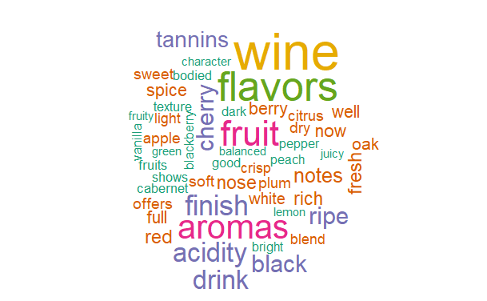

```r
library(wordcloud)
library(RColorBrewer)
# Setear un valor semilla
set.seed(42)
# Nube de palabras en colores; palabras con frecuencia m?nima de 70
wordcloud(names(freq), freq,min.freq=70,colors=brewer.pal(6,"Dark2"))
```

#### Es posible identificar clusters de algun tipo entre los datos analizados?

Es posible, pero al eliminar valores que no son muy usados la mayoría desaparece. Para respetar el proceso visto en clases se hará este proceso, pero con valores muy grandes de “sparse”. se observa que comienzan a aparecer a los **0.6**, se usará *0.9* para tener suficientes datos.

```r
dtmr2 = removeSparseTerms(dtm, sparse = 0.9)
inspect(dtmr2)
```

```
<<DocumentTermMatrix (documents: 1000, terms: 31)>>
Non-/sparse entries: 5795/25205
Sparsity           : 81%
Maximal term length: 7
Weighting          : term frequency (tf)
Sample             :
     Terms
Docs  acidity aromas black drink finish flavors fruit palate ripe wine
  125       1      1     0     0      1       0     2      0    2    1
  144       1      1     0     0      2       1     2      0    2    0
  148       0      0     4     0      0       1     0      1    0    1
  205       1      0     0     1      1       1     0      1    0    0
  259       0      0     1     0      1       2     1      1    1    1
  268       1      0     1     1      0       0     1      0    1    2
  420       1      0     1     1      0       0     1      0    0    2
  676       0      2     1     0      1       1     1      0    1    1
  678       1      1     2     1      1       0     1      1    1    0
  693       1      0     0     0      1       0     0      1    0    1
```

Se procede entonces a buscar clustering por particionamiento. Esto se hará usando Kmeans con un numero de clusters de 3:

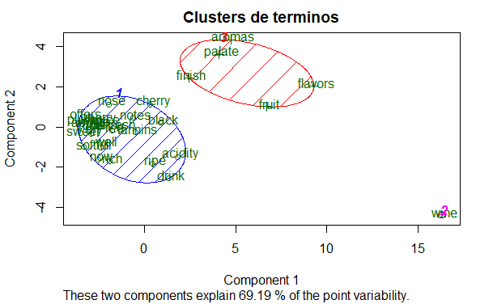

```r
library(fpc)
nroClusters = 3
kfit = kmeans(distMatrix, nroClusters)
clusplot(as.matrix(distMatrix), kfit$cluster, color=T, shade=T, labels=2, lines=0, main="Clusters de terminos")
```

[output not shown]

Evidentemente la palabra mas usada es vino, lo cual era de esperarse dado el contexto.

Como adicional se revisan las palabras representativas dentro de cada uno de los clusters:

```r
# Para chequear palabras representativas dentro de cada cluster
for (i in 1: nroClusters)
{
  cat(paste("cluster ", i, ": ", sep = ""))
  s = sort(kfit$centers[i,], decreasing = T)
  cat(names(s)[1:5], "\n")
}
```

[output not shown]

> Nota: Este documento se encuentra escrito sin tildes ni caracteres especiales a proposito, con el fin de evitar problemas de formato.

# todo esto es extra, lo dejo en caso de que sea util para las otras preguntas

### Graficos

```r
library(stringi)
library(ggplot2)
library(Rcpp)
```

[figure not shown]

```r
# Crear un marco de datos, con columnas de igual largo
wf = data.frame(term=names(freq),occurrences=freq)
# Dibujar t?rminos que aparecen m?s de 150 veces
p = ggplot(subset(wf, freq>150), aes(term, occurrences))
# "Identity" asegura que la altura de cada barra es proporcional al valor del datos mapeado en el eje y
p = p + geom_bar(stat="identity")
# Especificar que las etiquetas del eje x se muestren en un ?ngulo de 45 grados y horizon-
# talmente justificada (chequear si no fuera as?, es decir: angle = 0).
p = p + theme(axis.text.x=element_text(angle=45, hjust=1))
p
```

```r
# De ser necesario, seleccionar repositorio: BioC software, para esta secci?n
# https://www.bioconductor.org/packages/release/bioc/html/graph.html
source("https://bioconductor.org/biocLite.R")
```

```
Bioconductor version 3.7 (BiocInstaller 1.29.6), ?biocLite for help
```

```r
biocLite("graph")
```

[output not shown]

```
installation path not writeable, unable to update packages: survival
```

```r
source("https://bioconductor.org/biocLite.R")
```

```
Bioconductor version 3.7 (BiocInstaller 1.29.6), ?biocLite for help
```

```r
biocLite("Rgraphviz")
```

[output not shown]

```
installation path not writeable, unable to update packages: survival
```

```r
#library(graph)
library(Rgraphviz)
# Dibujar relaciones entre t?rminos que tengan una frecuencia no menor a 160
freq.terms = findFreqTerms(dtm,lowfreq=160)
plot(dtm, term = freq.terms, corThreshold = 0.12, weighting = T)
```

[output not shown]